# Computational Statistics 7.3: Goodness of fit and hypothesis testing

## Goodness of fit and hypothesis testing

### Overview

This lesson introduces the concepts of $R^2$ as a measure of goodness of fit and extend the techniques of hypothesis testing to regression models.

### Objectives

After completing this module, students should be able to:

1. Explain the meaning and application of $R^2$ and how to calculate it.
2. Evaluate and interpret the statistical significance of estimated regression coefficients.
3. Calculate the estimated coefficient standard errors from a bivariate regression.
4. Estimate bivarate regression models using the built-in `R`functions and interpret the results.

### Readings

Schumacker, Chapter 16.

## Hypothesis testing in regression models

In the previous lesson we learned how to estimate the OLS regression parameters. But, as everything in statistics, are the estimated parameters actually different than zero or they are simply different because of random chance? That is, how confident are we that the estimated parameters are different than zero?

**The implication:** Note that the implication here is that: if the estimated slope parameter, $\beta_{1}$, is statistically equal to zero, then the there is no statistical relation between $x$ and $y$ - technically, we can say that, at least the variables are not linearly related -. This is the basis of hypothesis testing in the context of the regression model.

**Formalization of the hypohteses:**

$H_0$: $x$ and $y$ are not linearly related $\equiv$ $\beta_1 = 0$.

$H_1$: $x$ and $y$ are linearly related $\equiv$ $\beta_1 \neq 0$.

### Standard Errors

Again, for the sake of brevity and simplicity I’ll skip the derivation, but the equations for the standard error of $\beta_0$ and $\beta_1$ are:

$$se_{\beta_0} = se_{\hat{y}} \sqrt{ \frac{\sum x_i^2}{n \sum (x_i - \bar{x})^2}}$$

$$se_{\beta_1} = se_{\hat{y}} \frac{1}{\sqrt{\sum (x_i - \bar{x})^2}}$$

Where,
$$se_{\hat{y}} = \sqrt{ \frac{\sum (y_i-\hat{y}_i)^2 }{n-2}}$$

### T-statistics

Once we compute the standard errors, the test proceeds exactly as we’ve always done it, using a *t test*.

1. **Calculate t statistic:**

For instance, if we got $\beta_{1} = 0.31$ and a $se_{\beta_{1}} = .10$, the t statistic is simply $(0.31-0)/0.10 = 3.1$.

2. **Calculate degree of freedom:**

The degree of freedom for a regression is $n - k - 1$, where $k$ is the number of variables; so in this case, it is $n - 1 -1 = n-2$.

3. **Choose test type, significance level and find the threshold values:**

As usual, we almost always do a two-tailed test here, so with a significance level of $\alpha = 0.05$ and an $n$ of 23, the threshold values are:

```r
alpha <- 0.05
n <- 23
k <- 1
df <- n - k - 1
qt(c(alpha/2, 1- alpha/2), df)
```

```
## [1] -2.079614  2.079614
```

4. **Conclusion:**

Since $3.1 > 2.08$ we can **reject the null hypothesis that there is no linear relation between $x$ and $y$**.

### Confidence Intervals

We can also present the 95% confidence interval on the estimated parameter:
$$\beta_{1} = 0.31 \pm 2.08 \times 0.10 = 0.31 \pm 0.208 = [0.102, 0.518]$$
As usual, because of uncertainty, the interpretation of the computed CI is: we are 95% confident that quantitative relation between $x$ and $y$ is between 0.102 and 0.518.

Note that because zero is not included in the confidence interval we can reject the null hypothesis that there is no linear relation.

## Goodness of fit

The $R^2$ is essentially a measure of **the proportion of the total variation in $y$ explained by $x$.**

If every time $y_i$ is above $\bar{y}$, $x_i$ is too (by a proportional amount), then $x$ explains the variation of $y$ relatively well.

But, if we are less able to predict $y_i$ with $x_i$, then less of the variation in Y is explained by X.

### $R^2$ Definition

**We define $R^2$ as:**

$$\begin{eqnarray*}
R^{2} & =& \frac{\text{Total Sum of Squares - Sum of Squared Errors}}{\text{Total Sum of Squares}} \\
&= &\frac{TSS-SSE}{TSS}
\end{eqnarray*}$$

1. **Define the total variation in Y**

This is very much like the variance in Y and is called the **Total Sum of Squares** or TSS:

$$TSS = \sum_{i} (y_{i} - \bar{y})^{2}$$

The TSS is a *measure of the total variation of Y around its mean*.

2. **Define the Sum of Squared Errors (defined in previous lesson)**

$$SSE = \sum_{i} (y_{i} - \hat{y}_{i})^{2}$$

The values of the $R^2$ are bounded between 0 and 1. Therefore, the $R^2$ is an standardized measure of how good is the model fitting the data.

### $R^2$ Interpretation (pt 2)

**If the model is deterministic:** $\hat{y}_i = y_i$ for every i, then SSE is 0 and the $R^2$ is, of course equal to 1.

**If the model is purely stochastic:** $x$ explains none of the variation in $y$, and basically we do no better than just guessing $\bar{y}$ for any given $y_i$; in this instance, the SSE equals the TSS ($\hat{y}_{i} = \bar{y}$), and $R^2$ equals 0.

**$R^{2}$ is also sometimes called the *proportional reduction in error* (ie, the reduction in the TSS).**

### $R^2$ Interpretation (pt 2)

If $R^{2} = 0.3$:

- 30% of the variation in y is explained by the model, or,
- We have reduced the error by 30% compared to simply guessing the average.

If $R^2$ is $1$:

- 100% of the variation in $y$ is explained by the model, or,
- We have reduced the error by 100% and explained all the variation.

If $R^2$ is 0:

- 0% of the variation in $y$ is explained by the model, or,
- We have reduced the error not at all, and explained none of the variation with the model.

### Estimating the regression model in `R`

In the previous lesson we estimated the parameters of the model *manually*. But that’s tedious and you can make coding mistakes. Regressions are so common in statistical analysis that there are dozens of packages in `R` dedicated to running regressions.

The default built-in function to estimate a model is $lm()$, `lm` s stands for **l**inear **m**odels.

Let’s simulate some data to test the `lm()` function:

```r
set.seed(1)
n <- 100 # number of observations
x <- rnorm(n,3,2)
y <- 5 + 3*x + rnorm(n,0,10)
df <- data.frame(x=x,y=y)

#Estimation
olsModel <- lm(y~x,data=df)
summary(olsModel)
```

```
Call:
lm(formula = y ~ x, data = df)

Residuals:
    Min      1Q  Median      3Q     Max
-18.768  -6.138  -1.395   5.394  23.462

Coefficients:
            Estimate Std. Error t value Pr(>|t|)
(Intercept)   4.6390     1.9826    2.34   0.0213 *
x             2.9947     0.5386    5.56 2.34e-07 ***
---
Signif. codes:  0 '***' 0.001 '**' 0.01 '*' 0.05 '.' 0.1 ' ' 1

Residual standard error: 9.628 on 98 degrees of freedom
Multiple R-squared:  0.2398,    Adjusted R-squared:  0.232
F-statistic: 30.91 on 1 and 98 DF,  p-value: 2.335e-07
```

Interpretation:

1. **Residuals**: Is just a description of the distribution of the errors$(\epsilon_{i}= y_i - \hat{y}_i)$. Not particularly informative.
2. The first column are the **values for $\beta_0$ (Intercept) and $\beta_1$ (x).** The second column are shows the standard errors.
3. The third column is the **t statistic**, which is just column 1 divided by column 2. Because the default assumption of the null hypothesis is zero, this column can be calculated simply by dividing the estimated parameter by the estimated standard error (columns (1) by (2)).
4. The final column is the **(two-tailed) p-value**, which for instance for the $\beta_1$, is just equal to `2*pt(5.56,98,lower.tail=F)`.
5. The output also shows the **$R^2$**, as well as the **adjusted $R^2$** and the **F statistic**, which we will discuss in the next module.

### Plotting regression lines with ggplot2

We can also easily plot the regression line using `ggplot2`:

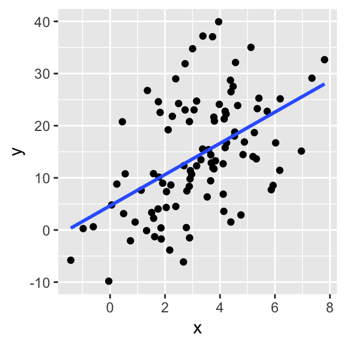

```r
suppressMessages(library(ggplot2))
ggplot(df, aes(x=x, y=y)) + geom_point() + geom_smooth(method=lm, se=FALSE)
```

This adds the regression line from `lm`, without the 95% confidence band. If we want to show the confidence band we can do,

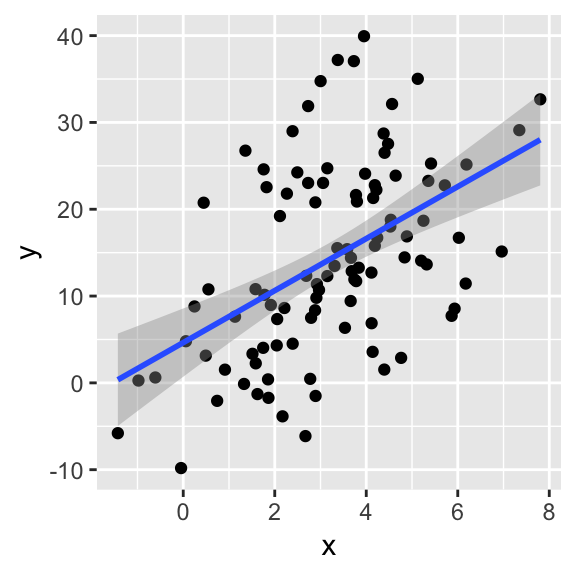

```r
ggplot(df, aes(x=x, y=y)) + geom_point() + geom_smooth(method=lm)
```

### Plotting 95% CI around regression lines

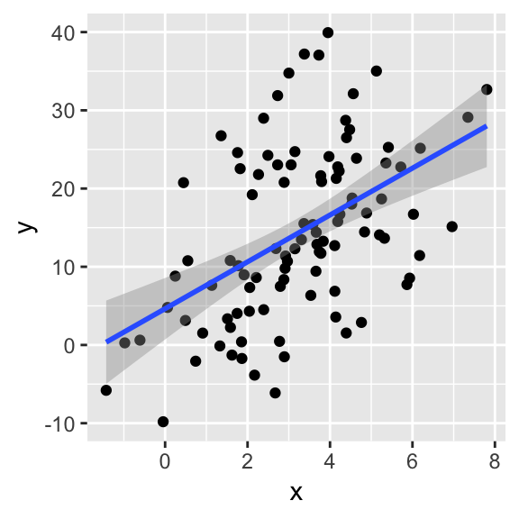

```r
ggplot(df, aes(x=x, y=y)) + geom_point() + geom_smooth(method=lm)
```

The shaded area in the previous graph is not a measure of the spread of the data points, just a measure of variation the best fit relative to the observed values.

- The shaded area is essentially a 95% CI for each fitted value.
- Remember that the intercept and the slope are, like all sampling-based estimates, fundamentally uncertain, just as the sample mean is, and therefore, the fitted values.
- The gray area combines the uncertainty in the intercept (ie, the line could be higher or lower) and the uncertainty in the slope (ie, the line could be steeper or flatter).
- Since we carefully distinguish between $\mu$, the true population mean, and $\bar{x}$, the sample mean, we should similarly carefully distinguish between the true $\beta$ and the sample-based estimate, which we generally call $\hat{\beta}$.